# Lab #1B - R Markdown and other `R` Essentials

This lab builds on Part 1A of the Introduction to R lab and focuses on R Markdown, packages/libraries, and a few additional topics.

## The Layout of R Studio

After you open `RStudio`, the first thing you’ll want to do is open a file to work in. You can do this by navigating: `File -> New File -> R Script`, which will open a new window in the top left of the `RStudio` interface for you to work in. At this point you should see four panels:

1. Your *R Script* (top left): is like a text-file that stores your code while you work on it. At any point you can send some or all of the code in your *R Script* to the *Console* to execute. You can also type commands directly into the *Console*.
2. The *Console* (bottom left) will echo any code you run, and it will display any textual/numeric output generated by your code.
3. Your *Environment* (top right) shows you the names of data sets, variables, and user-created functions that have been loaded into your work space and can be accessed by your code.
4. The *Files/Plots/Help viewer* (bottom right) will display graphics generated by your code and a few other useful entities (like help documentation and file trees).

[figure not shown]

## Packages

To facilitate more complex tasks in `R`, many people have developed their own sets of functions known as *packages*. If you plan on working with a new package for the *first time*, it must be installed:

```r
install.packages("ggplot2")
install.packages("dplyr")
```

Once a package is installed, it still needs to be loaded into your R session using the `library()` function (or `require()`) before its contents can be used. This is automatically done for you in some online servers. However, if you are working on your own desktop version of R/RStudio you will need to `install.packages()`.

You’ll need to re-load a package *every time* you open `R Studio`, but you’ll *only need to install it once*.

```r
library(ggplot2) # Now we can use any functions from the ggplot2 package
```

## R Markdown (RMD files)

“R Script” files contain only executable `R` code and comments. `R Studio` supports several other types of files, some of which use the “Markdown” authoring framework. An “R Markdown” file allows you to both:

1. Write and execute `R` code
2. Generate a high quality, reproducible report

To use R Markdown, you’ll need the `rmarkdown` package:

```r
install.packages("rmarkdown")
library("rmarkdown")
```

Once you have the package installed and loaded, you can create a new R Markdown file by selecting: `File -> New File -> R Markdown`.

At the top of the document is the **header**:

- This section initiated by three ‘-’ characters and closed by another three ‘-’ characters
- It contains the title, author, etc. that appears at the top of the document created by your code
- You can use it to add elements like a table of contents, page numbers, etc.

The second thing you’ll see is a **code chunk**:

- Code chunks are initiated by $\text{```\{r\}}$ and closed by $\text{```}$
- The $\text{```}$ wrappers tell R Markdown that what appears inside is code that should be executed. The first code chunk, initiated by $\text{```\{r setup\}}$ sets up options that will be used in executing your `R` code when your report is built. For now, you should keep this chunk as it appears and place your actual code inside of other code chunks.
- You can execute the `R` code in a chunk by clicking the small green arrow in the upper right corner. You can also highlight individual code pieces and execute them using *Ctrl-Enter*.

Next you’ll see **section headers**:

- Sections are created using strings of the $\#$ character.
- The number of $\#$ characters used determines the level (size) of the header.

Finally, R Markdown allows you to type **ordinary text** outside of code chunks. Thus, you can easily integrate written text into the same document as your code and its output.

The primary purpose of R Markdown is to create documents that blend R code, output, and text into a polished report. To generate this document you must compile your R Markdown file using the “Knit” button (a blue yarn ball icon) located towards the upper left part of your screen.

**Setting up a new R Markdown File**:

1. Create a new R Markdown file: `File -> New File -> R Markdown`.
2. Delete all of the template code that appears beneath the “r setup” code block (everything below line 11).
3. Change the title to “Lab #1” and the author to your name(s).

**Question #1**:

- Create a section label in you RMD file using three $\#$ characters followed by “Question 1”.
- Create an R chunk
- Read in the IowaCityHomeSales data
- Use a command that shows how many rows and columns are in the data frame.
- Knit the RMD file to see the output.

All data for the R Tutorials can be found here: [R Tutorial Data](https://github.com/grinnell-statistics/Grinnell_R_Tutorials/tree/main/data)

To read in the IowaCityHomeSales data we use the following command:

```r
my_data <- read.csv("https://grinnell-statistics.github.io/Grinnell_R_Tutorials/data/IowaCityHomeSales.csv")
```

**Question #2**:

- Create a new section label for “Question 2”.
- Create an R chunk. In this chunk we will be using the dplry package.
- Create a new data frame called SmallHomeData, that only includes houses with 2 or less bedrooms.
- Use a command that shows how many rows and columns are in this new data frame.

**Question #3**: R Markdown will use LaTex typesetting for any text wrapped in $\$$ characters. For example, $\$\text{\\beta}\$$ will appear as a the Greek letter $\beta$ after you knit your document. To practice this, add a new section label for Question #3 and below it include $\$\text{H_0: \\mu = 0}\$$ in a sentence (the sentence can say anything, but it should *not* be inside an R code chunk or a section header).

## Coercion

Part 1 of Lab #1 introduced three important types of vectors:

1. *numeric vectors* - for example: `x = c(1,2,3)`
2. *character vectors* - for example: `x = c("A","B","C")`
3. *logical vectors* - for example: `x = c(TRUE, FALSE, TRUE)`

Many functions require their inputs be of a certain type. Fortunately, data can be *coerced* into another type using the `as.` family of functions:

```r
## A character vector where the text strings are numbers
x <- c("1","12","123")
typeof(x)
```

```
## [1] "character"
```

```r
## Coerce 'x' to a numeric vector
x <- as.numeric(x)
x
```

```
## [1]   1  12 123
```

```r
typeof(x)
```

```
## [1] "double"
```

**Question #4**:

- Create a new section label for “Question 4”.
- Read in the data from https://grinnell-statistics.github.io/Grinnell_R_Tutorials/data/HappyPlanet.csv
- Show code that identifies what the variable type for “Region”
- Change “Region” into a character variable.

## Missing Data

Real data sometimes contain **missing values**, which `R` stores as the special element `NA`. Missing values may be present in your raw data, but they can also be introduced by coercion or other operations/functions:

```r
## The second element is a blank space
x <- c("1"," ","123")
typeof(x)
```

```
## [1] "character"
```

```r
## Coerce to a numeric vector (stored as 'y'), notice the NA
y <- as.numeric(x)
y
```

```
## [1]   1  NA 123
```

Missing values can cause problems for many functions, but some functions have arguments that control how missing values are handled. The example below shows how to remove any missing values when calculating the mean of `y`:

```r
mean(y) ## Doesn't handle the missing value
```

```
## [1] NA
```

```r
mean(y, na.rm = TRUE) ## Removes the missing value
```

```
## [1] 62
```

If missing values are removed in any part of an analysis, you should track and report the identities of the cases that were excluded. You can use the `is.na` function to help locate these cases.

```r
is.na(y) ## Returns TRUE if the value is missing
```

```
## [1] FALSE  TRUE FALSE
```

```r
which(is.na(y))  ## Uses the which function to return the positions where is.na() returns "TRUE"
```

```
## [1] 2
```

Another useful function is `na.omit`, which will subset a data frame to remove any rows that contain missing data in any variable. This function is demonstrated on the Happy Planet data below:

```r
my_data <- read.csv("https://grinnell-statistics.github.io/Grinnell_R_Tutorials/data/HappyPlanet.csv")


## Store the subset without missing data
my_data_without_na <- na.omit(my_data)

## Compare dimensions
dim(my_data)
```

```
## [1] 143  11
```

```r
dim(my_data_without_na)
```

```
## [1] 141  11
```

**Question #5**: Find the median value of the variable “GDPperCapita” in the Happy Planet data, removing any missing values *in this variable* if necessary. Report the country names corresponding to any missing values that you removed (if applicable).

## Factor Variables

Many functions will coerce character variables into **factors**.

On the surface you might not notice any difference, but internally a factor relies upon a set of categorical labels known as *levels*. By default, these labels are ordered alphabetically, but in some circumstances you’ll want to organize them yourself.

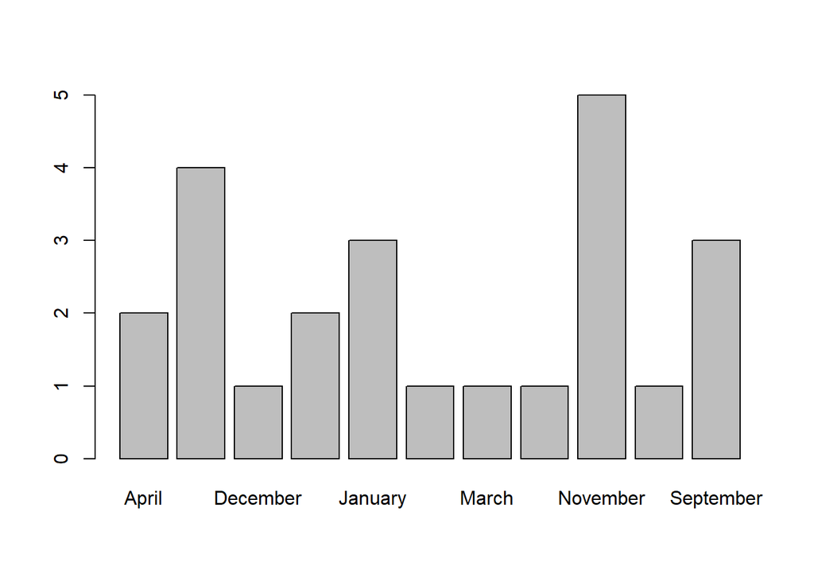

```r
## A vector containing different months
mons <- c("March","April","January","November","January", "September","October","September","November","August","January","November",
          "November","February","May","August",   "July","December","August","August","September","November", "February","April")

## Convert it to a factor
mons_unordered = factor(mons)

## Notice the factor defaults to alphabetical order
barplot(table(mons_unordered))
```

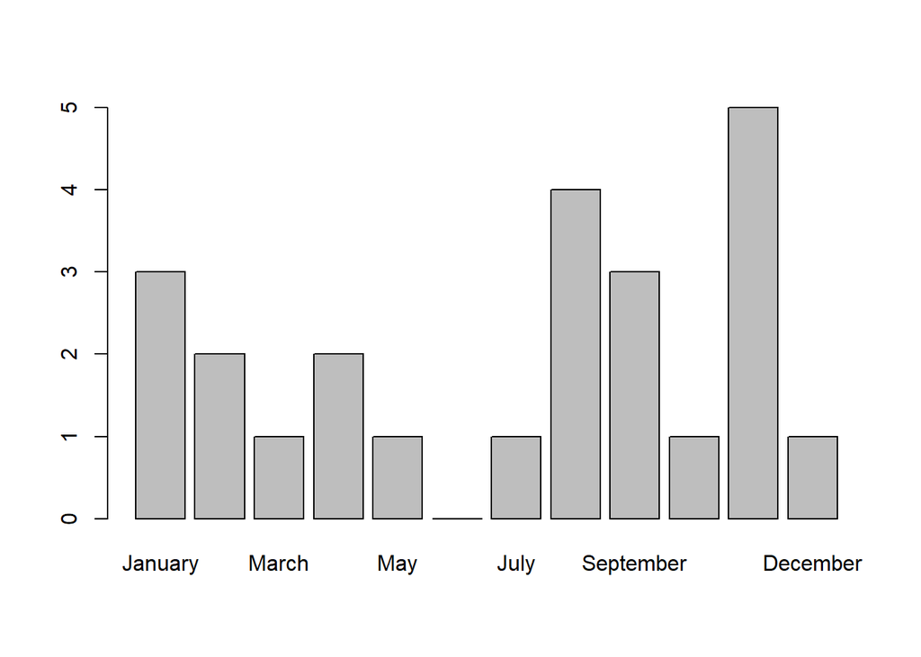

```r
## Convert to a factor with ordering specified by the "levels" argument
mons_ordered = factor(mons_unordered, levels= c("January","February","March","April","May","June",
                                                "July","August","September","October","November","December"),
                        ordered = TRUE)

## Notice the new ordering (useful for data visualization!)
barplot(table(mons_ordered))
```

**Question #6**:

The code below loads the “colleges” data set. Recall that this data set contains information pertaining to all primarily undergraduate institutions with at least 400 full-times students in the 2019-20 academic year.

https://grinnell-statistics.github.io/Grinnell_R_Tutorials/data/Colleges2019.csv

- **Part A**: Create a subset of these data that contains all schools that admit less than 50% of applicants (an “Adm_Rate” less than 50%) and are located in the “Great Lakes” region. You should use this subset in Parts B and C.
- **Part B**: Using the subset created in Part A, find the average value of “Salary10yr_median”, the median salary of a school’s alumni 10 years after their graduation. Remove missing data if necessary, but be sure to report the identity of any colleges that were removed.
- **Part C**: The “Great Lakes” region consists of 5 different states: IL, IN, MI, OH, and WI. Using the subset created in Part A, create a bar plot that displays the number of colleges (meeting the criteria specified in Part A) in each of these states in descending order (you may examine the frequency table to determine this ordering “by hand”).

## Practice

The data available at the URL below contains information from the Ames Assessor’s Office used in computing assessed values for individual residential properties sold in Ames, IA from 2006 to 2010:

https://grinnell-statistics.github.io/Grinnell_R_Tutorials/data/AmesHousing.csv

A more detailed description can be [found at this link](https://jse.amstat.org/v19n3/decock/DataDocumentation.txt)

- **Part A**: Read these data into `R` and store in a data frame named `ames_housing`. Then check the type of the variable `MS.SubClass` and compare it with the description of this variable given in the link above. Based upon your assessment, should this variable coerced to a different type? Briefly explain.
- **Part B**: Find the number of homes in this data set with missing values for the variable `Garage.Type`. *Hint*: you can use the `sum()` function on a logical vector to count the number of `TRUE` values.
- **Part C**: Create a subset containing homes with a missing value for the variable `Garage.Type`. What is the average `Garage.Area` of these homes?
- **Part D**: Using the variable `Exter.Cond` (exterior condition), create an ordered factor that goes from “Poor” condition (a value of `Po`) to “Excellent” condition (a value of `Ex`) following the order and definitions given in the detailed description for this variable. Use the `barplot()` and `table()` functions to construct a bar chart using your ordered factor variable.